# Projet_sujet6

### 3.3 Etape 2 : Supposons que les colonnes de Y ne sont pas indépendantes

Dans ce cas ci nous réécrivons le modèle de la forme suivante :
$$Y\Sigma^{-1/2}_q = XB\Sigma^{-1/2}_q +
E\Sigma^{-1/2}_q$$
On veut alors estimer la matrice $\hat{\Sigma}^{-1/2}_q$ de taille $q$x$q$. Pour cela nous comparons plusieurs modèles `AR1`, `ARMA`, et `non paramétrique`.

#### 3.3.1 Choix de la meilleure méthode d’estimation de $\Sigma^{-1/2}_q$

```r
result=whitening_choice(residuals,c("AR1","nonparam","ARMA"),pAR=1,qMA=1)
result
```

```
##          Pvalue    Decision
## AR1       0.965 WHITE NOISE
## nonparam  0.995 WHITE NOISE
## ARMA 1 1  0.965 WHITE NOISE
```

`pAR` : In the case where `typeDep="ARMA"` it corresponds to the parameter **p** of the **ARMA(p,q)** modelling.

`qMA` : In the case where `typeDep="ARMA"` it corresponds to the parameter **q** of the **ARMA(p,q)** modelling.

Pour chacun des modèles on a une p_value très haute : on peut donc choisir n’importe lequel des trois modèles.Nous allons donc nous intéresser par la suite à chacun de ces trois modèles.

(ARMA peut parfois permettre interprétations)

#### 3.3.2 Blanchiment, estimation de B et selection de variables

- **Non paramétrique :**

Calculs :

```r
#Stockage du Sigma^{-1/2}
np_square_root_inv_hat_Sigma=whitening(residuals,"nonparam")   #,pAR=1,qMA=0)

Freq_np=variable_selection(Y,X,np_square_root_inv_hat_Sigma,nb_repli=10000,parallel=FALSE)

print("Variable selection  : OK")
head(Freq_np)
```

```r
#save(Freq_np, file ='freq_np.RData')
load('freq_np.RData')
```

Graphes :

```r
colnames(Freq_np)<-c('Names_of_Y','Names_of_X','frequency')
head(Freq_np)
```

```
##         Names_of_Y Names_of_X frequency
## 1 m_a.Aminoadipate X1Elevated    0.9816
## 2 m_a.Aminoadipate      X1Low    0.9902
## 3 m_a.Aminoadipate   X1Medium    0.9878
## 4 m_a.Aminoadipate       X2EI    0.7381
## 5 m_a.Aminoadipate       X2LI    0.6556
## 6        m_Alanine X1Elevated    0.9965
```

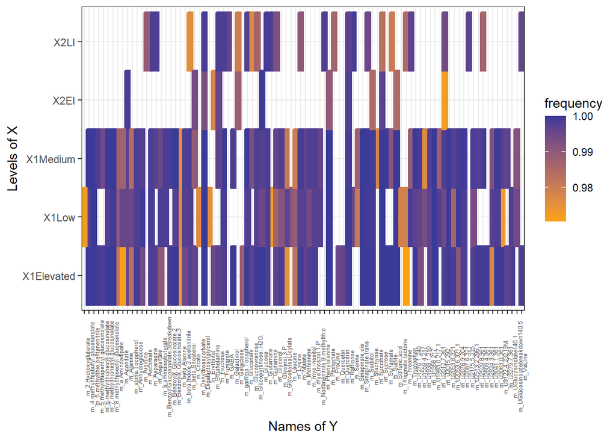

```r
# Here we can consider the names of Y as numerical since they correspond
# to the ratio m/z of the metabolites.
#Freq_np$Names_of_X<-sub('X2','',Freq_np$Names_of_X)
#Freq_np$Names_of_Y<-as.numeric(gsub('X','',gsub('\\.1$','',Freq_np$Names_of_Y)))

p<-ggplot(data=Freq_np[Freq_np$frequency>=0.97,],
        aes(x = Names_of_Y, y = Names_of_X,
        color = frequency, fill = frequency )) +
geom_tile(size = 0.75) +
scale_color_gradient2(midpoint = 0.97, mid = "orange") +
scale_fill_gradient2(midpoint = 0.97, mid = "orange") +
theme_bw() +
theme(axis.text.x = element_text(angle = 90, size=5)) +
ylab("Levels of X") + xlab("Names of Y")
p
```

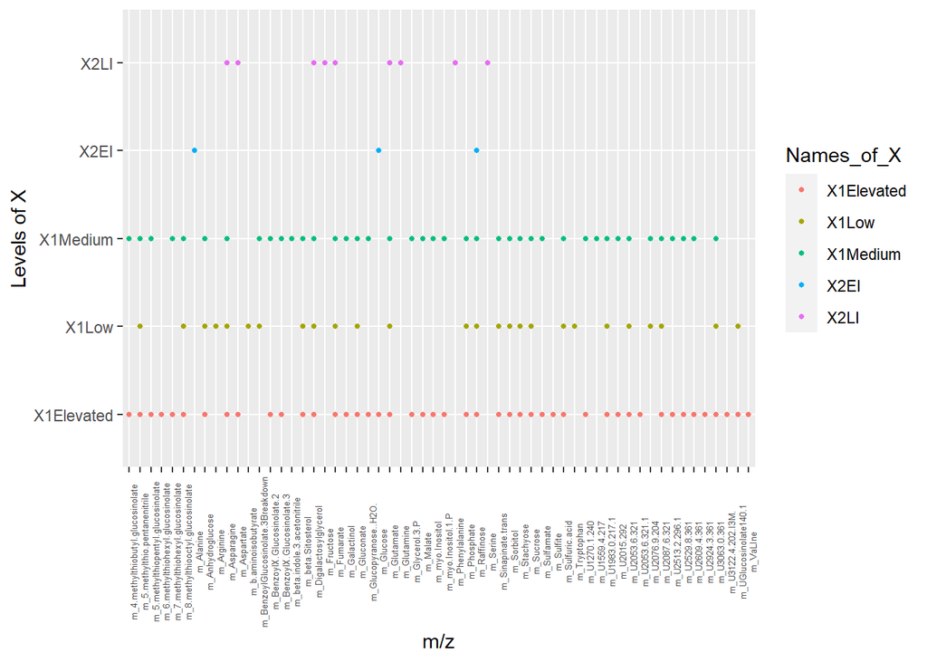

```r
#To avoid false postive we only consider the variables that are always selected (with a frequency equal to one)

p<-ggplot(data=Freq_np[Freq_np$frequency>=SEUIL,],
          aes(x=Names_of_Y,y=Names_of_X,color=Names_of_X))+
  geom_point(size=1)+theme(axis.text.x = element_text(angle = 90, size=5))+ylab('Levels of X')+xlab('m/z')
p
```

- **ARMA :**

Calculs :

```r
arma_square_root_inv_hat_Sigma=whitening(residuals,"ARMA", pAR=1,qMA=1)   #,pAR=1,qMA=0)

Freq_arma=variable_selection(Y,X,arma_square_root_inv_hat_Sigma,nb_repli=10000,parallel=FALSE)
```

```r
#save(Freq_arma, file ='freq_arma.RData')
load('freq_arma.RData')
```

Graphes :

```r
colnames(Freq_arma)<-c('Names_of_Y','Names_of_X','frequency')
head(Freq_arma)
```

```
##         Names_of_Y Names_of_X frequency
## 1 m_a.Aminoadipate X1Elevated    0.0136
## 2 m_a.Aminoadipate      X1Low    0.0023
## 3 m_a.Aminoadipate   X1Medium    0.0033
## 4 m_a.Aminoadipate       X2EI    0.0036
## 5 m_a.Aminoadipate       X2LI    0.0032
## 6        m_Alanine X1Elevated    0.9956
```

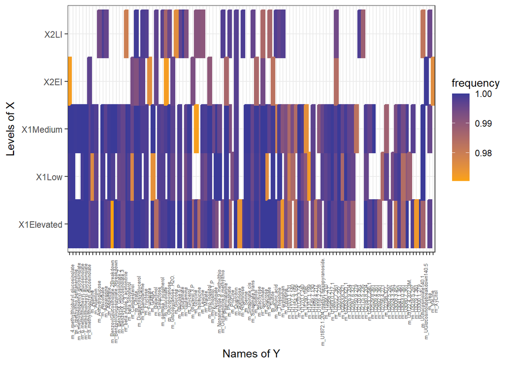

```r
# Here we can consider the names of Y as numerical since they correspond
# to the ratio m/z of the metabolites.

p<-ggplot(data=Freq_arma[Freq_arma$frequency>=0.97,],
        aes(x = Names_of_Y, y = Names_of_X,
        color = frequency, fill = frequency )) +
geom_tile(size = 0.75) +
scale_color_gradient2(midpoint = 0.97, mid = "orange") +
scale_fill_gradient2(midpoint = 0.97, mid = "orange") +
theme_bw() +
theme(axis.text.x = element_text(angle = 90, size=5)) +
ylab("Levels of X") + xlab("Names of Y")
p
```

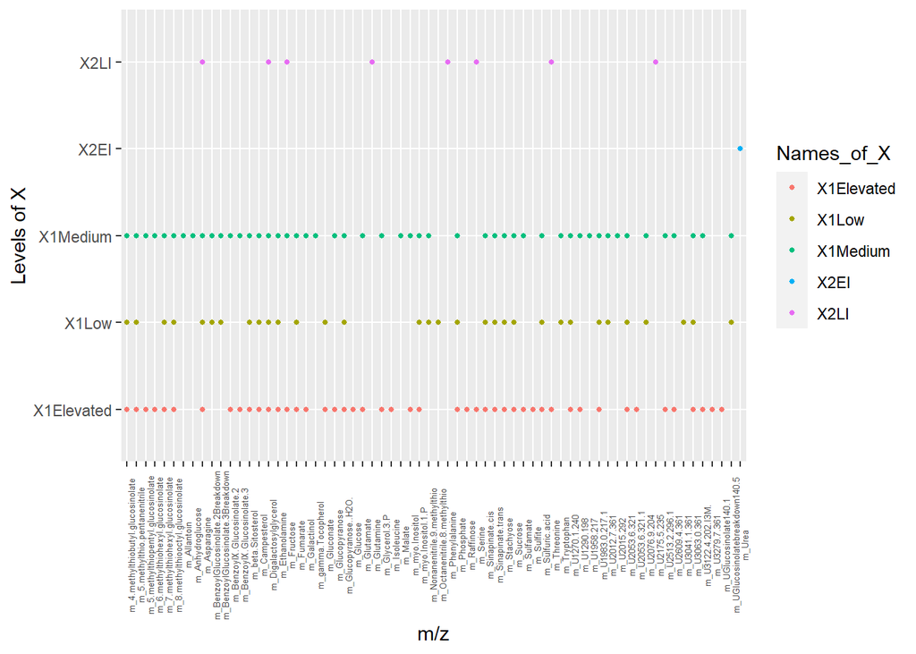

```r
#To avoid false postive we only consider the variables that are always selected (with a frequency equal to one)

p<-ggplot(data=Freq_arma[Freq_arma$frequency>=SEUIL,],
          aes(x=Names_of_Y,y=Names_of_X,color=Names_of_X))+
  geom_point(size=1)+theme(axis.text.x = element_text(angle = 90, size=5))+ylab('Levels of X')+xlab('m/z')
p
```

- **AR1 :**

Calculs :

```r
ar_square_root_inv_hat_Sigma=whitening(residuals,"AR1")   #,pAR=1,qMA=0)

Freq_ar=variable_selection(Y,X,ar_square_root_inv_hat_Sigma,nb_repli=10000,parallel=FALSE)
```

```r
#save(Freq_ar, file ='freq_ar.RData')
load('freq_ar.RData')
```

Graphes :

```r
colnames(Freq_ar)<-c('Names_of_Y','Names_of_X','frequency')
head(Freq_ar)
```

```
##         Names_of_Y Names_of_X frequency
## 1 m_a.Aminoadipate X1Elevated    0.0132
## 2 m_a.Aminoadipate      X1Low    0.0018
## 3 m_a.Aminoadipate   X1Medium    0.0027
## 4 m_a.Aminoadipate       X2EI    0.0043
## 5 m_a.Aminoadipate       X2LI    0.0040
## 6        m_Alanine X1Elevated    0.9970
```

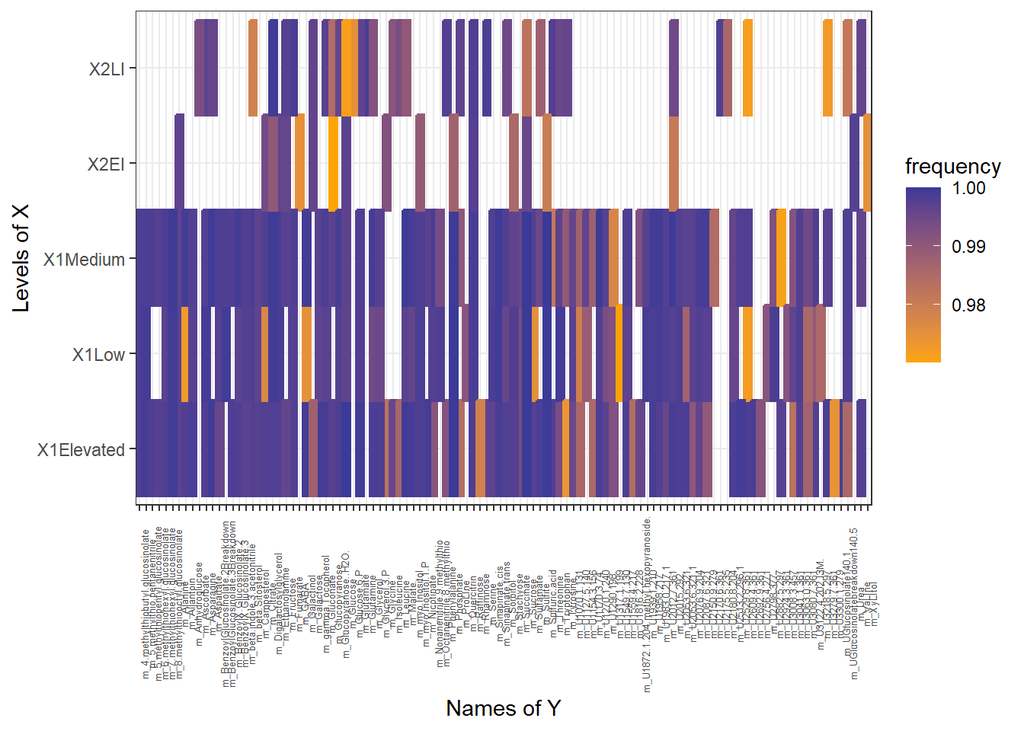

```r
# Here we can consider the names of Y as numerical since they correspond
# to the ratio m/z of the metabolites.

p<-ggplot(data=Freq_ar[Freq_ar$frequency>=0.97,],
        aes(x = Names_of_Y, y = Names_of_X,
        color = frequency, fill = frequency )) +
geom_tile(size = 0.75) +
scale_color_gradient2(midpoint = 0.97, mid = "orange") +
scale_fill_gradient2(midpoint = 0.97, mid = "orange") +
theme_bw() +
theme(axis.text.x = element_text(angle = 90, size=5)) +
ylab("Levels of X") + xlab("Names of Y")
p
```

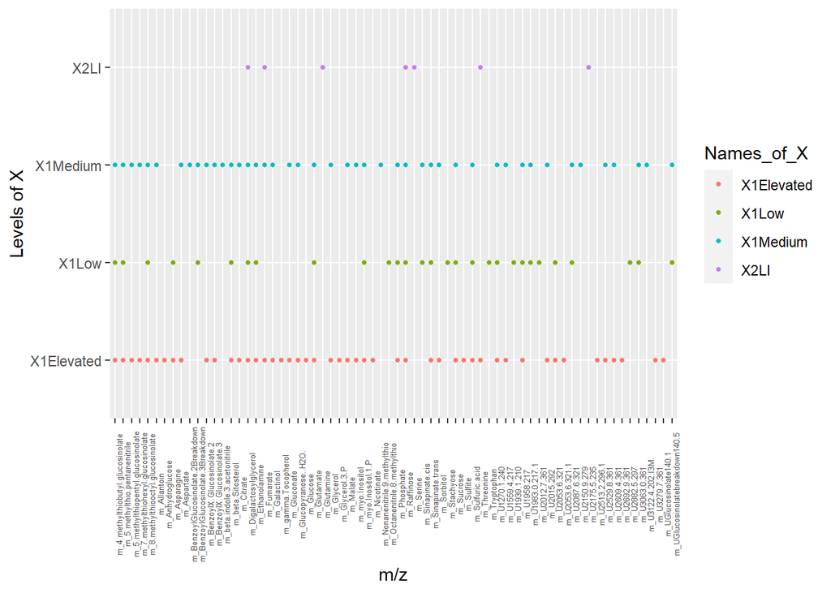

```r
#To avoid false postive we only consider the variables that are always selected (with a frequency equal to one)

p<-ggplot(data=Freq_ar[Freq_ar$frequency>=SEUIL,],
          aes(x=Names_of_Y,y=Names_of_X,color=Names_of_X))+
  geom_point(size=1)+theme(axis.text.x = element_text(angle = 90, size=5))+ylab('Levels of X')+xlab('m/z')
p
```

#### 3.3.3 Choix des variables

```r
ordered_np = Freq_np[order(Freq_np$frequency,decreasing=T),]

ordered_arma = Freq_arma[order(Freq_arma$frequency,decreasing=T),]

ordered_ar = Freq_ar[order(Freq_ar$frequency,decreasing=T),]

ordered = data.frame('fNP'=ordered_np$frequency,
                       'fARMA'=ordered_arma$frequency,
                       'fAR'=ordered_ar$frequency)
ordered$seuil = rep(SEUIL, length(ordered_np$frequency))

ordered$index = c(1:length(ordered_np$frequency))
```

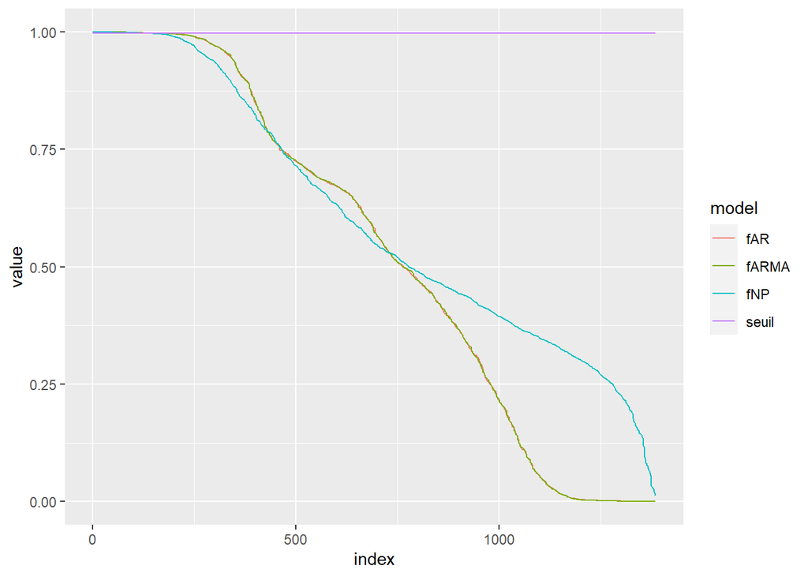

```r
df <- gather(ordered, key = "model", value = "value",
c("fNP", "fARMA", "fAR", "seuil"))
ggplot(df, aes(x=index, y = value, colour =model)) +
geom_line()
```

On choisit les varaibles présentes dans les différents modèles.

```r
res.NP = subset(Freq_np, Freq_np$frequency >= SEUIL)
res.ARMA = subset(Freq_arma, Freq_arma$frequency >= SEUIL)
res.AR = subset(Freq_ar, Freq_ar$frequency >= SEUIL)

metabolites = res.NP[which((res.NP$Names_of_Y %in% res.ARMA$Names_of_Y) & (res.NP$Names_of_Y %in% res.AR$Names_of_Y)),]
dim(metabolites)
```

```
## [1] 101   3
```

```r
metabolites
```

```
##                              Names_of_Y Names_of_X frequency
## 16                         m_Asparagine X1Elevated    0.9986
## 17                         m_Asparagine      X1Low    0.9990
## 18                         m_Asparagine   X1Medium    0.9987
## 20                         m_Asparagine       X2LI    0.9986
## 50                          m_Glutamine       X2LI    0.9981
## 51                          m_Glutamate X1Elevated    0.9985
## 52                          m_Glutamate      X1Low    0.9983
## 53                          m_Glutamate   X1Medium    0.9987
## 55                          m_Glutamate       X2LI    0.9993
## 95                             m_Serine       X2LI    0.9992
## 102                        m_Tryptophan      X1Low    0.9989
## 121                   m_beta.Sitosterol X1Elevated    0.9982
## 122                   m_beta.Sitosterol      X1Low    0.9981
## 123                   m_beta.Sitosterol   X1Medium    0.9989
```

[output cut: 87 more lines]

Graphes :

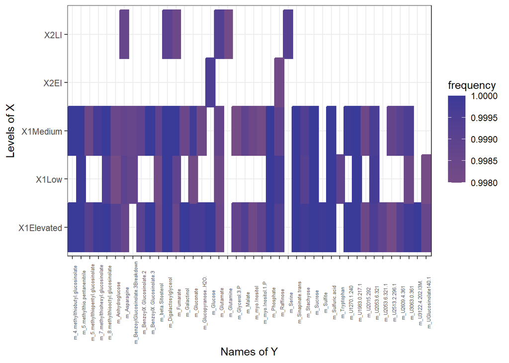

```r
p<-ggplot(data=metabolites,
        aes(x = Names_of_Y, y = Names_of_X,
        color = frequency, fill = frequency )) +
geom_tile(size = 0.75) +
scale_color_gradient2(midpoint = 0.99, mid = "orange") +
scale_fill_gradient2(midpoint = 0.99, mid = "orange") +
theme_bw() +
theme(axis.text.x = element_text(angle = 90, size=5)) +
ylab("Levels of X") + xlab("Names of Y")
p
```

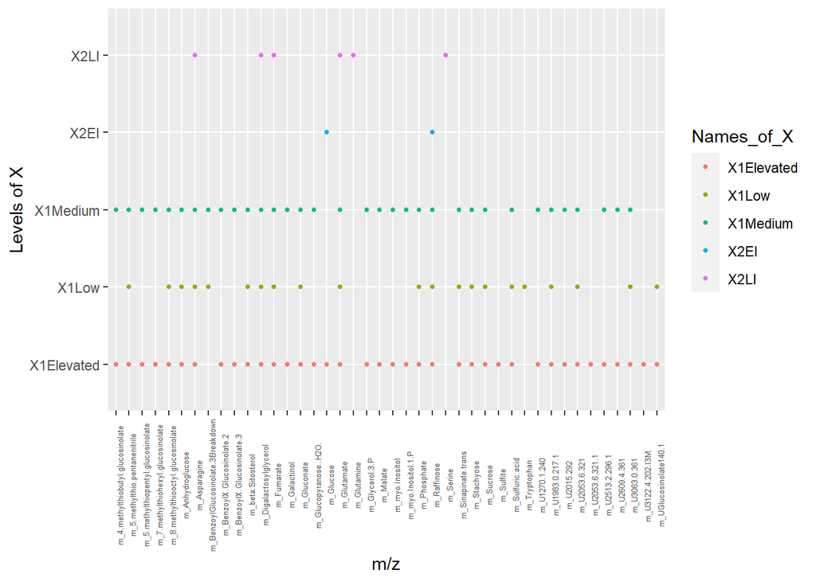

```r
p<-ggplot(data=metabolites,
          aes(x=Names_of_Y,y=Names_of_X,color=Names_of_X))+
  geom_point(size=1)+theme(axis.text.x = element_text(angle = 90, size=5))+ylab('Levels of X')+xlab('m/z')
p
```

```r
final_meta = levels(factor(res.no_whitening[which(res.no_whitening$Names_of_Y %in%  metabolites$Names_of_Y), 1]))

length(final_meta)
```

```
## [1] 37
```

```r
final_meta
```

```
##  [1] "m_4.methylthiobutyl.glucosinolate"  "m_5.methylthio.pentanenitrile"
##  [3] "m_5.methylthiopentyl.glucosinolate" "m_7.methylthiohexyl.glucosinolate"
##  [5] "m_8.methylthiooctyl.glucosinolate"  "m_Anhydroglucose"
##  [7] "m_Asparagine"                       "m_BenzoylGlucosinolate.3Breakdown"
##  [9] "m_BenzoylX.Glucosinolate.2"         "m_BenzoylX.Glucosinolate.3"
## [11] "m_beta.Sitosterol"                  "m_Digalactosylglycerol"
## [13] "m_Fumarate"                         "m_Gluconate"
## [15] "m_Glucopyranose..H2O."              "m_Glucose"
## [17] "m_Glutamate"                        "m_Glycerol.3.P"
## [19] "m_Malate"                           "m_myo.Inositol"
## [21] "m_myo.Inositol.1.P"                 "m_Phosphate"
## [23] "m_Raffinose"                        "m_Sinapinate.trans"
## [25] "m_Stachyose"                        "m_Sucrose"
## [27] "m_Sulfite"                          "m_Sulfuric.acid"
## [29] "m_Tryptophan"                       "m_U1270.1.240"
## [31] "m_U1983.0.217.1"                    "m_U2015.292"
## [33] "m_U2053.6.321"                      "m_U2513.2.296.1"
## [35] "m_U2609.4.361"                      "m_U3063.0.361"
## [37] "m_UGlucosinolate140.1"
```